# Recalling Words

```r
# Play the chunk above and this one to get the data into your Console
View(Friendly)
?Friendly
```

## Background

Education is a very expensive industry with whose influence can make or break nations. Due to this, it’s very important that educators use the best methods available for helping students to learn.

A study was performed to determine whether one of three teaching methods (named *SFR*, *Before*, and *Meshed*) had a better impact on memory recall than the others.

- The SFR method randomly presents information for memorization during each trial session.
- The Before method presents the information successfully memorized before information not memorized in each successive trial session.
- The Meshed method alternates presenting the information successfully memorized with information not memorized.

##### Click here for further details

##### Click here to see the raw data

## Analysis

### Hypothesis

We’ll be testing to see if the two treatment groups, the ones that used the “Meshed” or “Before” methods, had the same difference in their medians when compared to the control group that used the “SFR” method.

This will require two independent samples tests: Meshed compared to SFR and Before compared to SFR. The Hypothesis and $\alpha$ are as follows.

$$H_0: \text{difference in medians = 0}$$

$$H_a: \text{difference in medians > 0}$$

Normally our $\alpha$ would equal .05 but since we will need to run multiple tests, I’ll conduct a Bonferroni correction and set $\alpha = .025$ for each of the tests.
$$\alpha = .025$$

Before we can determine what type of test we can do, we will need to check the normality of our data.

### Describe the Data

We’ll start by creating a number summary and a strip chart. From these we can see that the sample size is too small to assume normality.

```r
Friendly %>%
  group_by(condition) %>%
  summarise(min = min(correct),
            Q1 = quantile(correct, 0.25),
            mean = mean(correct),
            median = median(correct),
            Q3 = quantile(correct, 0.75),
            max = max(correct),
            sd = sd(correct),
            "Sample Size" = n()
            ) %>%
  pander()
```

| condition | min | Q1 | mean | median | Q3 | max | sd | Sample Size |
| --- | --- | --- | --- | --- | --- | --- | --- | --- |
| Before | 24 | 37.25 | 36.6 | 39 | 39.75 | 40 | 5.337 | 10 |
| Meshed | 30 | 36 | 36.6 | 36.5 | 38.75 | 40 | 3.026 | 10 |
| SFR | 21 | 25 | 30.3 | 27 | 38.5 | 39 | 7.334 | 10 |

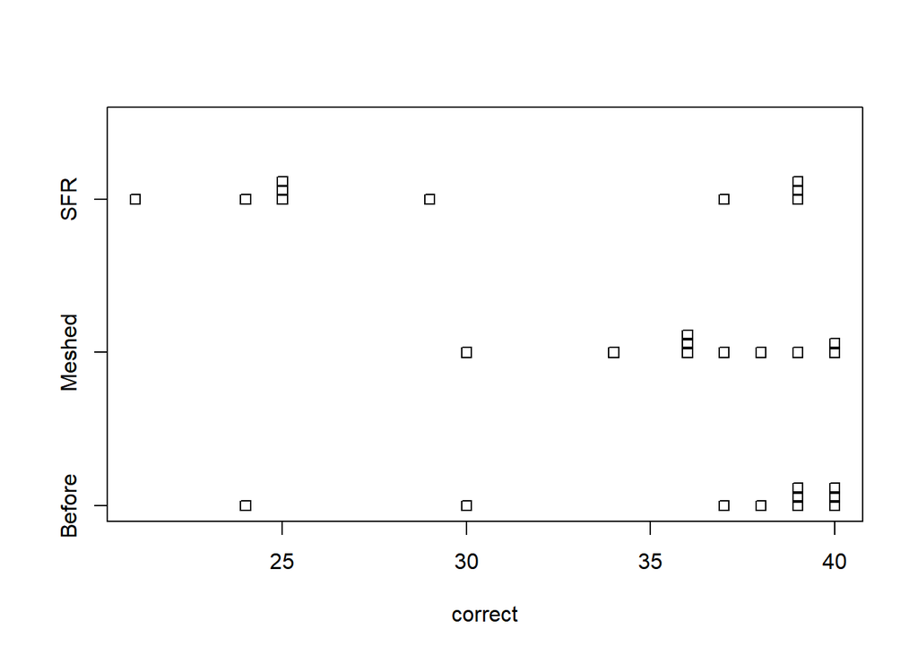

```r
stripchart(correct ~ condition,
           data = Friendly,
           method = "stack")
```

Since the sample size is small we’ll create a Q-Q plot of each of the three samples to check for normality. Most of the data appears to be normal, however since there are outliers and the sample is small we won’t be able to perform a t-Test and will need to conduct a Wilcoxon Test instead.

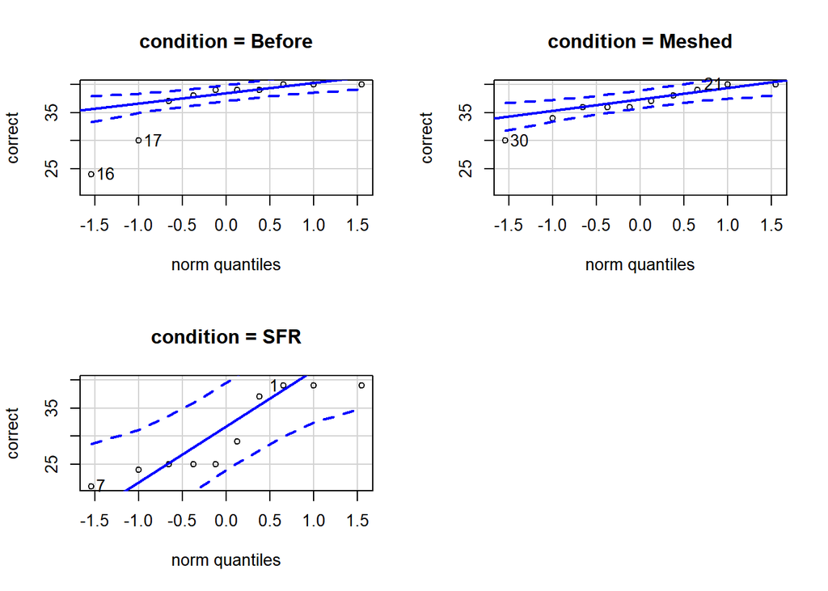

```r
qqPlot(correct ~ condition,
       data = Friendly)
```

### Make inferences

Now that we have determined what type of test we’ll conduct, I’ll set the official hypothesis.

The Wilcoxon Rank Sum Tests are as follows:

```r
wilcox.test(
  Friendly$correct[Friendly$condition == "Before"],
  Friendly$correct[Friendly$condition == "SFR"],
  mu = 0,
  alternative = "greater",
  conf.level = 0.95
) %>%
  pander()
```

Wilcoxon rank sum test with continuity correction: `Friendly$correct[Friendly$condition == "Before"]` and `Friendly$correct[Friendly$condition == "SFR"]`

| Test statistic | P value | Alternative hypothesis |
| --- | --- | --- |
| 76.5 | 0.02278 * | greater |

```r
wilcox.test(
  Friendly$correct[Friendly$condition == "Meshed"],
  Friendly$correct[Friendly$condition == "SFR"],
  mu = 0,
  alternative = "greater",
  conf.level = 0.95
) %>%
  pander()
```

Wilcoxon rank sum test with continuity correction: `Friendly$correct[Friendly$condition == "Meshed"]` and `Friendly$correct[Friendly$condition == "SFR"]`

| Test statistic | P value | Alternative hypothesis |
| --- | --- | --- |
| 72 | 0.05075 | greater |

Since the p-value for the “Before” method hypothesis is 0.02278, we have sufficient evidence to reject the null hypothesis for the “Before” method.

Since the p-value for the “Meshed” method hypothesis is 0.05075, we have insufficient evidence to reject the null hypothesis for the “Meshed” method.